# Pricing di Opzioni su FCOJ: un confronto tra ‘Black-76’ e simulazione Monte Carlo tra dati reali e scenari di stress.

Progetto per il Corso di Metodi stocastici per l’economia e la finanza - a.a. 2025/26

Francesco Dell’Anna (Matr. 20113413)

09/02/2026

# 1 Introduzione

Il mercato delle *commodities* (materie prime) è caratterizzato da un’elevata volatilità, influenzata da fattori esogeni imprevedibili come le condizioni climatiche o i report sui raccolti (come andremo a vedere nel nostro specifico caso). In questo contesto, i derivati finanziari, e in particolare le **Opzioni**, svolgono un ruolo cruciale per la copertura del rischio (*hedging*) e per la *speculazione*.

Il presente elaborato ha l’obiettivo di determinare il **Fair Value** (prezzo equo) di un’Opzione Put Europea sottoscritta su un contratto **Future** del Succo d’Arancia Concentrato Congelato (*Frozen Concentrated Orange Juice* - FCOJ). Lo studio adotta un approccio ibrido diviso in due fasi:

1. **Analisi Reale:** In questa prima fase, il modello viene stimato sulle attuali condizioni di mercato. Vengono utilizzate le serie storiche giornaliere del Future FCOJ (`OJ=F`) per il periodo compreso tra **01/07/2025 – 01/01/2026**, reperite dalla piattaforma *Investing.com*. Viene indicato come prezzo spot iniziale ($S_0$, o meglio $F_0$ per il Future) l’ultimo prezzo di chiusura disponibile. La volatilità ($\sigma$) non è assunta arbitrariamente, ma è stimata come **volatilità storica annualizzata** dei rendimenti logaritmici del semestre considerato. Si procede al calcolo del prezzo di un’opzione Put *At-The-Money* (ATM) con scadenza a 30 giorni ($T=30/252$), confrontando il risultato della formula di Black con la media dei payoff simulati via Monte Carlo.

Per modellare l’andamento del prezzo del Future ($F_t$), viene adottato il **Moto Browniano Geometrico (GBM)**, un processo stocastico a tempo continuo che assume solo valori positivi nonchè uno dei modelli fondamentali della finanza quantitativa, sotto la misura neutrale al rischio $\mathbb{Q}$. Poichè, come già detto, il sottostante è un contratto future (e non un’azione), viene perciò utilizzata la dinamica descritta dal “*Modello di Black-76*” che, a differenza del modello classico di Black-Scholes, considera un drift/tendenza del processo stocastico sotto la misura neutrale al rischio $\mathbb{Q}$ nullo, in quanto l’ingresso in un contratto future ha costo iniziale nullo e non richiede investimento di capitale, di conseguenza il termine di crescita si annulla e formalmente ciò si traduce nel fatto che il coefficiente della componente deterministica della **SDE** si riduce alla sola componente stocastica:

$$dF_t = 0 dt + \sigma F_t dW_t$$
dalla quale si ricava l’*equazione differenziale stocastica* che descrive l’evoluzione continua, indicata come:
$$dF_t = \sigma F_t dW_t$$
dove:

- $dF_t$ (*Variazione di prezzo*): indica quanto cambia il prezzo del future in un istante infinitesimale;
- $\sigma$ (*Volatilità*): indica l’incertezza, più è alta e più le oscillazioni del prezzo saranno maggiori;
- $dW_t$ (*White Noise*): è l’incremento di un moto browniano standard o processo di Wiener, che cattura la componente stocastica del processo che ha traiettorie continue con incrementi indipendenti. È una variabile estratta da una Normale con media 0 e varianza $dt$. La cosìdetta “fortuna/sfortuna”;
- $0 dt$ (*Assenza di drift*): questo perchè in un mondo neutrale al rischio, il prezzo atteso di un future tra un’istante è esattamente uguale al prezzo attuale, matematicamente si dice che il prezzo è una “*Martingala*” poichè è costante per l’assenza del *drift*.

Per il calcolo del prezzo dell’opzione sono stati confrontati due approcci distinti:

- **Approccio Analitico (Benchmark):** Basato sulla formula chiusa di **Black-76**, variante del modello Black-Scholes, ampiamente utilizzata per opzioni su futures e su obbligazioni. Mentre nella formula classica si sconta unicamente lo Strike-Price, in questa variante scontiamo anche il prezzo del Futures, poichè il suo pagamento avviene a scadenza.
- **Approccio Numerico:** Il **Metodo Monte Carlo**, basato sulla simulazione di $M$ traiettorie del sottostante e sul calcolo del valore atteso scontato del payoff:
  $$P_{MC} = e^{-rT} [\frac{1}{M} \sum_{i=1}^{M}
  \max(K - F_T^{(i)}, 0)]$$
2. **Scenario di Stress:** Nella seconda fase, il modello viene sottoposto a uno “stress test” qualitativo ispirato alla scena finale del film *“Una poltrona per due”* che rappresenta un caso di shock informativo. Si simula l’impatto di un evento macroeconomico estremo (il rilascio del “Resoconto sul raccolto”) in un contesto di altissima incertezza. Verranno modificati i parametri di input (ci sarà un innalzamento della volatilità implicita) per osservare come il modello di pricing reagisce a condizioni di “Panic Selling” o crolli improvvisi del sottostante, evidenziando le potenzialità della simulazione Monte Carlo nel visualizzare la distribuzione dei rischi (code grasse) rispetto alla rigidità della formula analitica.

Quindi le principali assunzioni teoriche del progetto includono:

- la **dinamica del prezzo del future** descritta da un *“Moto Browniano Geometrico (GBM)”*;
- **presenza** di mercati efficienti e **assenza** di arbitraggi, nel contesto della misura neutrale al rischio $\mathbb{Q}$;
- tasso di interesse privo di rischio $r$ costante per la durata dell’opzione.

In conclusione, con il seguente progetto si vuole **verificare** la capacità del *metodo Monte Carlo* di convergere al valore teorico, calcolato mediante la *formula di Black-76*, all’aumentare del numero di simulazioni $M$, confermando anche *la Legge dei Grandi Numeri*, ed infine adattanto il tutto ad uno scenario rappresentato da un film iconico delle vacanze natalizie come **“Una poltrona per due”**.

# 2 Analisi con Dati Reali

In questa sezione, calibreremo il modello utilizzando i dati di mercato reali scaricati da *Investing.com* relativi al periodo **01/07/2025 - 01/01/2026**. L’obiettivo è stimare la volatilità storica ($\sigma$) del Future FCOJ e utilizzarla per prezzare un’opzione Put a 30 giorni.

## 2.1 Importazione e Pulizia dei Dati

Carichiamo il dataset e prepariamo le serie storiche per l’analisi. Poiché i dati grezzi presentano la virgola come separatore decimale e un ordinamento cronologico inverso, è necessaria una fase di pulizia.

```r
# Lettura del file CSV
# dec = "," poichè il file scaricato da Investing.com usa la virgola come separatore per i decimali
nome_file <- "Future_FCOJ_01.07_01.01.csv"
data_raw <- read.csv(nome_file, stringsAsFactors = FALSE, dec = ",")

# Selezione delle colonne di interesse: Data e Prezzo di Chiusura ("Ultimo")
# Rinominiamo le colonne per facilità d'uso
df <- data.frame(
  Date = as.Date(data_raw$Data, format = "%d.%m.%Y"),
  Price = data_raw$Ultimo
)

# Ordinamento cronologico in ordine crescente
df <- df[order(df$Date), ]

# Visualizziamo le prime righe
head(df, 3)
```

```
##           Date  Price
## 129 2025-07-01 221.35
## 128 2025-07-02 207.25
## 127 2025-07-03 219.65
```

```r
# e le ultime righe per verifica
tail(df, 3)
```

```
##         Date Price
## 3 2025-12-29 206.3
## 2 2025-12-30 201.9
## 1 2025-12-31 205.2
```

Prima di procedere con il calcolo dei parametri, osserviamo l’andamento del prezzo del Future nel periodo selezionato per identificare eventuali trend o anomalie:

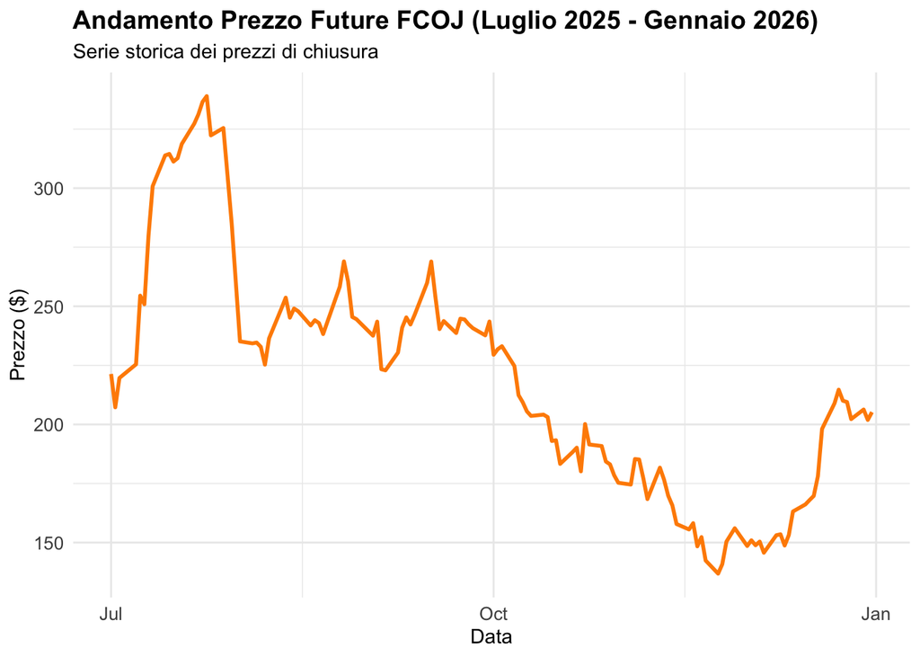

```r
# Carichiamo il pacchetto che usiamo per creare il grafico
library(ggplot2)
# Creazione del grafico
ggplot(data = df, aes(x = Date, y = Price)) +
  geom_line(color = "darkorange", linewidth = 1) +  # Arancione per non uscire fuori tema! :)
  labs(title = "Andamento Prezzo Future FCOJ (Luglio 2025 - Gennaio 2026)",
       subtitle = "Serie storica dei prezzi di chiusura",
       x = "Data",
       y = "Prezzo ($)") +
  theme_minimal() + # Tema pulito e professionale
  theme(plot.title = element_text(face = "bold", size = 14),
        axis.text = element_text(size = 10))
```

## 2.2 Stima della volatilità storica

Assumendo, come anticipato nell’introduzione, che il prezzo del future segua un *Moto Browniano Geometrico*, calcoliamo i rendimenti **logaritmici** giornalieri ($u_i$) e la loro deviazione standard per stimare la volatilità annualizzata ($\sigma$):

$$u_i =
\ln\left(\frac{F_i}{F_{i-1}}\right), \quad \sigma_{annua} =
\sigma_{giornaliera} \cdot \sqrt{252}$$

```r
# Calcolo dei log-returns
df$Log_Returns <- c(NA, diff(log(df$Price)))

# Rimozione dei valori NA (il primo giorno non ha rendimento)
returns_clean <- na.omit(df$Log_Returns)

# Stima della volatilità
vol_daily <- sd(returns_clean)
sigma <- vol_daily * sqrt(252)

# Definizione del prezzo corrente (F0)
F0 <- tail(df$Price, 1)

# Output dei parametri calibrati
cat("Prezzo Spot del Future (F0):", F0, "\n")
```

```
## Prezzo Spot del Future (F0): 205.2
```

```r
cat("Volatilità Storica Annualizzata (sigma):", round(sigma*100, 2), "%\n")
```

```
## Volatilità Storica Annualizzata (sigma): 66.33 %
```

## 2.3 Pricing mediante “Black-76” - Benchmark

Utilizzando questi parametri stimati siamo ora in grado di calcolare il **prezzo teorico di un’opzione Put ATM** (At-The-Money) con scadenza un mese (*30 giorni*). Poichè il sottostante è un future, utilizziamo la **Formula di Black-76**, formula che adatta la formula classica “Black-Scholes” trattando il prezzo forward come “prezzo spot” del sottostante nel modello, scontando il payoff al tasso risk-free, ed è ampiamente usato per opzioni su commodity futures, bond options e swaption, ed è definita come segue:

$$P_{Put} = e^{-rT}[K N(-d_2) - F_0
N(-d_1)]$$

```r
# Parametri dell'Opzione
r <- 0.05           # Tasso risk-free (5%)
T <- 30 / 252       # Scadenza (30 giorni su base annua 252)
K <- F0             # Strike Price (ATM, uguale al prezzo attuale)

# Calcolo di d1 e d2
d1 <- (log(F0 / K) + (0.5 * sigma^2) * T) / (sigma * sqrt(T))
d2 <- d1 - sigma * sqrt(T)

# Formula di Black per Put Option
# pnorm(x) è la funzione di ripartizione N(x) in R
bs_price <- exp(-r * T) * (K * pnorm(-d2) - F0 * pnorm(-d1))

cat("Prezzo Teorico (Black-76):", round(bs_price, 4))
```

```
## Prezzo Teorico (Black-76): 18.5847
```

Per comprendere il comportamento dell’opzione, visualizziamo come varia il premio (Prezzo Put) al variare del prezzo del sottostante ($F$), confrontandolo con il valore intrinseco (Payoff a scadenza). Con questo grafico si vuole rappresentare il valore che il mercato attribuisce alla possibilità che il prezzo si muova prima della scadenza. Più tempo manca, più la curva del *Fair Value* si alza rispetto al *Valore intrinseco*, ovvero il guadagno immediato se l’opzione scadesse ora, e ciò è dovuto all’incertezza.

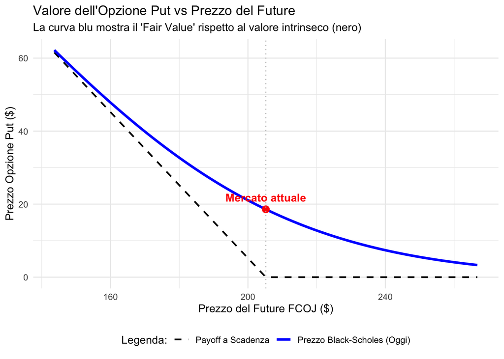

```r
# Creiamo un intervallo di prezzi possibili per il Future (da -30% a +30% rispetto a oggi)
F_range <- seq(from = F0 * 0.7, to = F0 * 1.3, length.out = 200) #asse delle ascisse

# Calcoliamo il Valore Intrinseco (Payoff immediato se scadesse oggi)
intrinsic_value <- pmax(K - F_range, 0) #payoff con scadenza oggi, per ognuno dei 200 punti

# Calcoliamo il Prezzo Teorico (Black-76) per ogni livello di prezzo
# Usiamo la stessa formula di Black definita prima
d1_vec <- (log(F_range / K) + (0.5 * sigma^2) * T) / (sigma * sqrt(T))
d2_vec <- d1_vec - sigma * sqrt(T)
bs_prices_vec <- exp(-r * T) * (K * pnorm(-d2_vec) - F_range * pnorm(-d1_vec)) #vettore dei prezzi b

# Creiamo il dataframe per ggplot
profile_data <- data.frame(
  Future_Price = F_range,
  Payoff = intrinsic_value,
  Option_Price = bs_prices_vec
)

# Grafico
ggplot(profile_data, aes(x = Future_Price)) +
  # Linea tratteggiata per il Payoff a scadenza
  geom_line(aes(y = Payoff, linetype = "Payoff a Scadenza"), color = "black", linewidth = 0.8) +
  # Linea continua per il Prezzo Black-Scholes oggi
  geom_line(aes(y = Option_Price, linetype = "Prezzo Black-Scholes (Oggi)"), color = "blue", linewidth = 1.2) +
  # Punto che indica la situazione attuale
  annotate("point", x = F0, y = bs_price, color = "red", size = 3) +
  annotate("text", x = F0, y = bs_price, label = "Mercato attuale", vjust = -1, color = "red", fontface = "bold") +
  # Linea verticale per lo Strike
  geom_vline(xintercept = K, linetype = "dotted", color = "gray") +

  scale_linetype_manual(name = "Legenda:", values = c("Prezzo Black-Scholes (Oggi)" = "solid", "Payoff a Scadenza" = "dashed")) +
  labs(title = "Valore dell'Opzione Put vs Prezzo del Future",
       subtitle = "La curva blu mostra il 'Fair Value' rispetto al valore intrinseco (nero)",
       x = "Prezzo del Future FCOJ ($)",
       y = "Prezzo Opzione Put ($)") +
  theme_minimal() +
  theme(legend.position = "bottom")
```

## 2.4 Pricing mediante “Metodo Monte Carlo”

Dopo aver ottenuto il **prezzo teorico** mediante l’utilizzo della formula Black-76, possiamo procedere con la *stima numerica* mediante il **Metodo Monte Carlo**. Simuleremo $M$ traiettorie possibili del prezzo del future alla scadenza $T$ e calcoleremo la media dei payoff scontati. Poichè i computer non sono in grado di calcolare equazioni differenziali continue ($dF_t$), per fare la simulazione è necessario usare la *soluzione esatta* dell’equazione per un intervallo di tempo finito $T$, è quindi necessario *discretizzare il processo*, ovvero trasformare l’equazione differenziale stocastica in un’equazione algebrica che descriva il prezzo dopo un intervallo di tempo finito. La dinamica simulata è espressa dalla soluzione esatta del GBM, come segue:

$$F_T = F_0 \cdot \exp\left(
-\frac{1}{2}\sigma^2 T + \sigma\sqrt{T}Z \right)$$
dove:

- $F_t$: indica il prezzo simulato alla scadenza, ovvero 30 giorni;
- $F_0$: indica il prezzo attuale, estrapolato dal file csv;
- $-\frac{1}{2}\sigma^2 T$: è una correzione matematica, definita *Correzione di Ito* necessaria perchè stiamo lavorando con logaritmi ed esponenziali, senza di essa il modello sovrastimerebbe il prezzo futuro;
- $Z$: indica un numero casuale estratto dalla Normale Standard ${N}(0,1)$.

```r
set.seed(123)       # Per la riproducibilità
M <- 50000          # Numero di simulazioni (elevato per una maggiore precisione)

# Generazione di M numeri casuali dalla Normale Standard
Z <- rnorm(M, mean = 0, sd = 1)

# Calcolo dei prezzi finali F_T per ogni scenario
FT_simulati <- F0 * exp(-0.5 * sigma^2 * T + sigma * sqrt(T) * Z)

# Calcolo del Payoff della Put per ogni scenario: max(K - FT, 0)
payoffs <- pmax(K - FT_simulati, 0)

# Calcolo del prezzo Monte Carlo (Media scontata)
mc_price <- exp(-r * T) * mean(payoffs)

# Calcolo dell'Errore Standard della stima
std_error <- sd(payoffs) / sqrt(M)

cat("Prezzo Monte Carlo:", round(mc_price, 4), "\n")
```

```
## Prezzo Monte Carlo: 18.6483
```

```r
cat("Intervallo di Confidenza 95%: [",
    round(mc_price - 1.96*std_error, 4), ", ",
    round(mc_price + 1.96*std_error, 4), "]\n")
```

```
## Intervallo di Confidenza 95%: [ 18.4375 ,  18.8591 ]
```

```r
cat("Differenza rispetto a Black-76:", round(mc_price - bs_price, 4))
```

```
## Differenza rispetto a Black-76: 0.0635
```

Visualizziamo la distribuzione dei prezzi finali del Future ($F_T$) generati dalla simulazione Monte Carlo. L’area a sinistra della linea rossa rappresenta gli scenari in cui l’opzione Put finisce *In-The-Money* (profittevole), ovvero quando il prezzo scende sotto lo Strike.

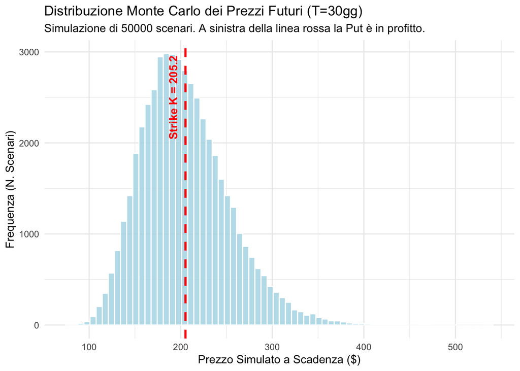

```r
# Creiamo un dataframe con i risultati della simulazione
# Usiamo il vettore 'FT_simulati' calcolato precedentemente
sim_data <- data.frame(Prezzi_Finali = FT_simulati)

ggplot(sim_data, aes(x = Prezzi_Finali)) +
  # Istogramma della distribuzione (bins = numero di barre)
  geom_histogram(bins = 70, fill = "lightblue", color = "white", alpha = 0.8) +

  # Linea verticale dello Strike Price (K)
  geom_vline(aes(xintercept = K), color = "red", linetype = "dashed", linewidth = 1) +

  # Etichetta per lo Strike Price
  annotate("text", x = K, y = M/20, label = paste("Strike K =", round(K, 2)),
           angle = 90, vjust = -1, color = "red", fontface = "bold") +

  # Titoli e assi
  labs(title = "Distribuzione Monte Carlo dei Prezzi Futuri (T=30gg)",
       subtitle = paste("Simulazione di", M, "scenari. A sinistra della linea rossa la Put è in profitto."),
       x = "Prezzo Simulato a Scadenza ($)",
       y = "Frequenza (N. Scenari)") +

  theme_minimal()
```

Questo istogramma rappresenta la distribuzione di probabilità empirica dei prezzi del future a scadenza, simulati mediante Monte Carlo. Si può notare come la sua forma descriva una distribuzione Log-Normale, coerente con l’ipotesi del **GBM** (prezzi non negativi); l’aresa sotto la curva a sinistra rappresenta visivamente la *probabilità* ($N(-d_2)$) che l’opzione finisca ITM.

Per dare più concretezza alla **natura stocastica** del processo, visualizziamo un campione di possibili traiettorie (*sentieri*) che il prezzo del future potrebbe percorrere nei prossimi 30 giorni:

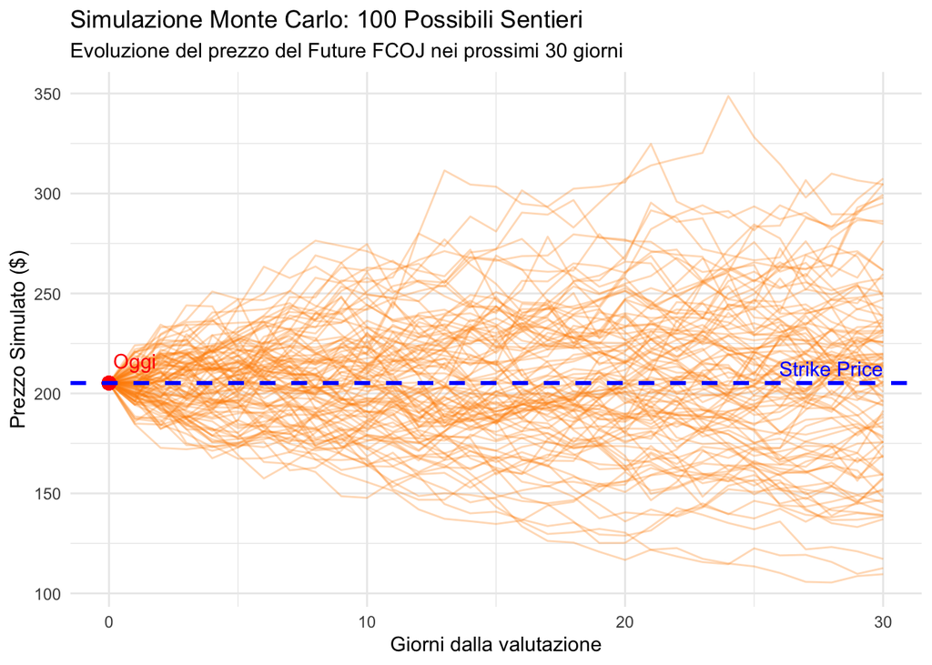

```r
# Parametri per il grafico
n_paths <- 100       # Definiamo un numero di sentieri pari a 100
n_steps <- 30        # 1 passo equivale ad 1 giorno
dt <- T / n_steps    # Intervallo di tempo (1 giorno in anni)

# Creiamo una matrice per salvare i prezzi: righe <- giorni, colonne <- sentieri
# Il giorno 0 (oggi) tutti partono da F0
paths_matrix <- matrix(NA, nrow = n_steps + 1, ncol = n_paths)
paths_matrix[1, ] <- F0 #nella prima riga della tabella inseriamo il punto di partenza

# Generazione dei sentieri passo dopo passo
set.seed(123) # Per riproducibilità
for(j in 1:n_paths) { #Ciclo esterno delle colonne, prima calcola tutta j e poi passa a j+1
  for(i in 1:n_steps) { #Ciclo interno delle righe, calcola ogni riga i-esima di j e poi di j+1
    # Z è il numero casuale giornaliero
    Z <- rnorm(1)
    # Formula iterativa: Prezzo domani = Prezzo oggi * exp(...)
    paths_matrix[i+1, j] <- paths_matrix[i, j] * exp(-0.5 * sigma^2 * dt + sigma * sqrt(dt) * Z)
  } #prezzo di domani = prezzo di oggi per la variazione
}

# Trasformiamo i dati per ggplot in quanto la matrice precedente è in formato wide e non è adatta al plotting
# Creiamo un dataframe con tre sole colonne: Giorno, ID_Sentiero, Prezzo
days <- 0:n_steps #crea l'asse temporale dei giorni
plot_data <- data.frame()

#creazione di una tabella temporanea per il sentiero j-esimo
for(j in 1:n_paths) {
  temp_df <- data.frame(
    Giorno = days,
    Prezzo = paths_matrix[, j],
    Sentiero = as.factor(j)
  )
  plot_data <- rbind(plot_data, temp_df) #rowbind, prende la plot_data e ci incolla la nuova tabella
}

# Grafico
ggplot(plot_data, aes(x = Giorno, y = Prezzo, group = Sentiero)) + #raggruppa i dati per sentiero e non per giorni
  # Disegna le linee dei sentieri (sottili e trasparenti)
  geom_line(color = "darkorange", alpha = 0.3, linewidth = 0.5) +

  # Aggiungi il prezzo iniziale (punto rosso)
  geom_point(aes(x = 0, y = F0), color = "red", size = 3) +
  annotate("text", x = 1, y = F0, label = "Oggi", color = "red", vjust = -1) +

  # Aggiungi la linea dello Strike (se il prezzo va sotto, la Put guadagna)
  geom_hline(aes(yintercept = K), color = "blue", linetype = "dashed", linewidth = 1) +
  annotate("text", x = n_steps, y = K, label = "Strike Price", color = "blue", vjust = -0.5, hjust = 1) +

  labs(title = "Simulazione Monte Carlo: 100 Possibili Sentieri",
       subtitle = "Evoluzione del prezzo del Future FCOJ nei prossimi 30 giorni",
       x = "Giorni dalla valutazione",
       y = "Prezzo Simulato ($)") +
  theme_minimal()
```

Si noti che i *“sentieri”* partono tutti dallo stesso punto di partenza, ovvero $F_0$, e successivamente si aprono allontanandosi e prendendo direzioni diverse l’uno dall’altro. Questo comportamento spiega, visivamente, la volatilità che aumenta con il passare del tempo ($\sigma \sqrt{T}$). La linea blu tratteggiata indica lo “Strike Price”, di conseguenza tutti quei sentieri che finiscono sotto di essa indicano le simulazioni in cui la nostra **opzione put** finisce *In-The-Money*, cioè in profitto.

## 2.5 Analisi della convergenza

Per validare il metodo numerico possiamo analizzare *graficamente* come il prezzo stimato (**MC**) converge al valore tecnico (**B-76**) all’aumentare del numero di simulazioni:

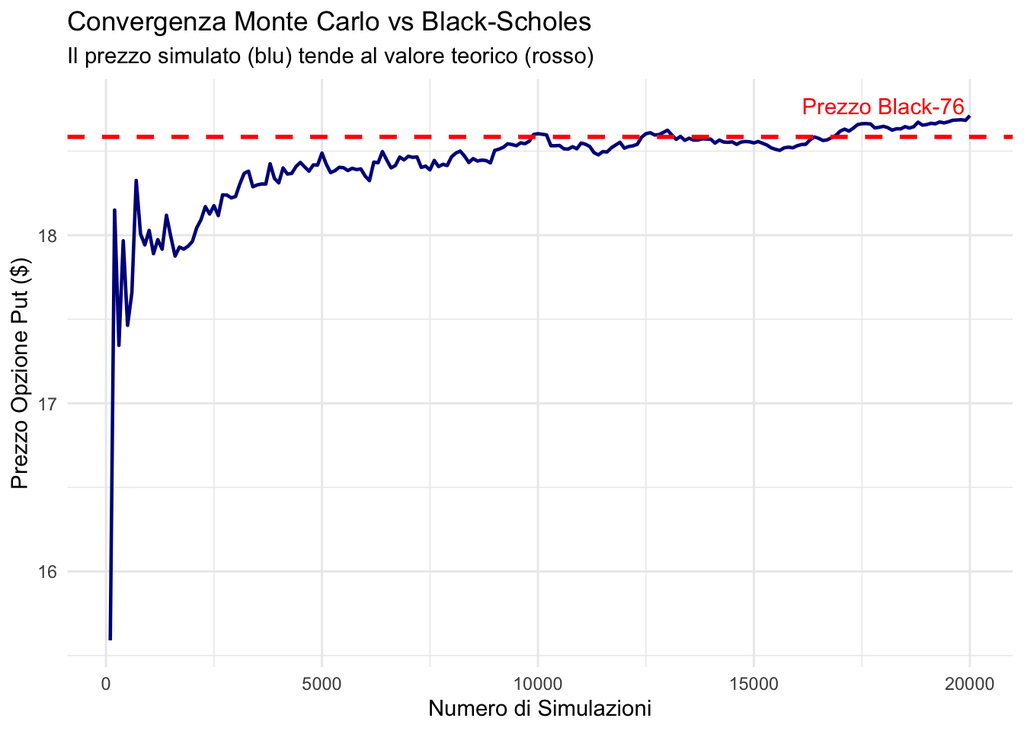

```r
# Simuliamo la convergenza progressiva
n_steps <- seq(100, 20000, by = 100) #creiamo un vettore che parte da 100 e arriva a 20000 a salti di 100
mc_estimates <- numeric(length(n_steps)) #creiamo il vettore nel quale saranno inseriti

# Per efficienza usiamo la somma cumulativa dei payoff già generati
#Prendiamo un sottoinsieme delle simulazioni fatte sopra per il grafico
payoff_subset <- payoffs[1:20000]
#media dei payoff futuri, cumsum ci evita di ricalcolare la media per ogni step
cumulative_means <- cumsum(payoff_subset) / (1:20000)
mc_convergence <- exp(-r * T) * cumulative_means #sconto i payoff futuri

# Creiamo un dataframe per il grafico
conv_data <- data.frame(
  Simulazioni = 1:20000,
  Prezzo_MC = mc_convergence
)


library(ggplot2)
ggplot(conv_data[seq(100, 20000, 100), ], aes(x = Simulazioni, y = Prezzo_MC)) +
  geom_line(color = "darkblue", linewidth = 0.8) +
  geom_hline(aes(yintercept = bs_price), color = "red", linetype = "dashed", linewidth = 1) +
  annotate("text", x = 18000, y = bs_price * 1.01, label = "Prezzo Black-76", color = "red") +
  labs(title = "Convergenza Monte Carlo vs Black-Scholes",
       subtitle = "Il prezzo simulato (blu) tende al valore teorico (rosso)",
       x = "Numero di Simulazioni",
       y = "Prezzo Opzione Put ($)") +
  theme_minimal()
```

L’analisi grafica ci conferma che, nonostante le oscillazioni iniziali tipiche dell’aleatorietà, l’errore si riduce progressivamente, per un $M$ di simulazioni $≈$ 10’000, stabilizzandosi intorno al valore teorico ottenuto dalla formula chiusa di Black-76.

# 3 Stress Test - Scenario “Una poltrona per due”

Il concetto chiave di questa sezione è l’Event Risk (Rischio Evento). Nel film, il mercato è paralizzato in attesa del “Crop Report” (il rapporto sul raccolto delle arance) e i due fratelli Duke, spregiudicati squali di Wall Street e co-protagonisti del film, sono sicuri di conoscere in anteprima il suo esito e di conseguenza in che direzione si muoverà il prezzo delle arance. Qui entrano in gioco gli altri due protagonisti del film, Winthorpe e Valentine, che per vendicarsi del raggiro subito dai fratelli Duke riescono ad impadronirsi del report originale e a sostituirlo con uno falso che annunciava un raccolto delle arance compromesso dall’inverno rigido, il quale avrebbe fatto schizzare in alto i prezzi di quest’ultime. Nella realtà il raccolto delle arance sarà abbondante il che determinerà un crollo del prezzo subito dopo l’uscita della notizia. Nel film gli strumenti finanziarii che fanno da padrone nella scena finale sono proprio i **futures**, ovvero contratti standardizzati che vengono scambiati sui mercati regolamentati. Un future sul succo d’arancia concentrato surgelato prevede che la quantità della materia prima scambiata sia pari a 15’000 libbre ($≈$ 6’800 kg). I Duke “ordinano” al loro braccio destro di comprare quanto più succo di arancia possibile appena apre il mercato, anche se il prezzo dovesse salire, in quanto, convinti del fatto che il raccolto sia stato pessimo e che il prezzo del succo salirà vertiginosamente in seguito alla pubblicazione del report, essi avendo già comprato molto succo potranno poi rivenderlo ad un prezzo largamente più alto. Difatti, ammalliati dai presunti profitti che da lì a poco avrebbero generato, arrivano ad acquistare contratti ad un prezzo di $1,42$ $. A questo punto entrano in gioco i protagonisti principali, che iniziano a stipulare accordi per vendere il succo al prezzo appena citato e man mano stipulano anche accordi a prezzi notevolmente più bassi, sapendo che il prezzo di lì a poco crollerà. Subito dopo l’uscita del report il prezzo crolla e Winthorpe e Valentine iniziano a riacquistare contratti a prezzi notevolmente inferiori fino ad arrivare a $0,29$ $ per contratto.

Cosa succede matematicamente nello scenario in cui si è in attesa dell’uscita del “Crop report”?

- L’incertezza esplode: La volatilità ($\sigma$) schizza alle stelle prima dell’annuncio.
- Il Prezzo dell’Opzione sale: Anche se il prezzo del succo è fermo, il valore della Put aumenta solo per via della volatilità (Vega, ovvero la sensibilità del prezzo di un opzione ai cambiamenti della volatilità).
- Il Crollo (Post-report): Una volta uscita la notizia (“Raccolto normale”), il prezzo del Future crolla.

Quindi in questa seconda fase, abbandoniamo l’ipotesi di normalità dei mercati per simulare un evento di **Stress Test** ispirato al finale del film. Lo scenario simula l’attesa del “Crop Report”, rappresentativo di un evento macroeconomico binario che genera estrema incertezza.

## 3.1 Setup dei Parametri di Stress

In prossimità di un annuncio cruciale, la volatilità storica perde di significato. Il mercato “prezza” l’incertezza aumentando drasticamente la volatilità implicita. Ipotizziamo due cambiamenti rispetto alla fase dell’**analisi reale**:

- **Volatilità da Stress ($\sigma_{stress}$):** Incrementiamo la volatilità all’**80%** (rispetto al valore storico calcolato prima) per riflettere il panico pre-report.
- **Prezzo di Mercato ($F_{high}$):** Ipotizziamo che il prezzo sia stato spinto in alto dalla speculazione (es. +10% rispetto a oggi) in attesa di una gelata che distrugga il raccolto.

```r
# Definiamo i parametri di stress
sigma_stress <- 0.80   # 80% di volatilità (Scenario di panico)
F_high <- F0 * 1.10    # Il prezzo è salito del 10% per speculazione rialzista
K_stress <- F_high     # Ipotizziamo di comprare una Put ATM su questo nuovo prezzo

cat("--- PARAMETRI SCENARIO STRESS ---\n")
```

```
## --- PARAMETRI SCENARIO STRESS ---
```

```r
cat("Prezzo Future pre-report:", round(F_high, 2), "$\n")
```

```
## Prezzo Future pre-report: 225.72 $
```

```r
cat("Volatilità Stress:", sigma_stress * 100, "%\n")
```

```
## Volatilità Stress: 80 %
```

## 3.2 L’Impatto della Volatilità (Vega)

Calcoliamo quanto costerebbe la stessa opzione Put in condizioni normali in confronto a quanto costerebbe in condizioni di stress. Questo evidenzia il costo della protezione assicurativa durante le crisi (hedging).

```r
# Prezzo con volatilità normale (quella storica dell'analisi con dati reali)
price_normal <- exp(-r * T) * (K_stress * pnorm(-( (log(F_high/K_stress)+(0.5*sigma^2)*T)/(sigma*sqrt(T)) - sigma*sqrt(T) )) - F_high * pnorm(-( (log(F_high/K_stress)+(0.5*sigma^2)*T)/(sigma*sqrt(T)) )))

# Prezzo con volatilità da stress (80%)
d1_stress <- (log(F_high / K_stress) + (0.5 * sigma_stress^2) * T) / (sigma_stress * sqrt(T))
d2_stress <- d1_stress - sigma_stress * sqrt(T)
price_stress <- exp(-r * T) * (K_stress * pnorm(-d2_stress) - F_high * pnorm(-d1_stress))

# Creazione Tabella di confronto
comparison <- data.frame(
  Scenario = c("Mercato Normale (Analisi dati reali)", "Mercato Stress (Una poltrona per due)"),
  Volatilità = c(paste0(round(sigma*100, 1), "%"), paste0(round(sigma_stress*100, 1), "%")),
  Prezzo_Put = c(round(price_normal, 2), round(price_stress, 2))
)

print(comparison)
```

```
##                                Scenario Volatilità Prezzo_Put
## 1  Mercato Normale (Analisi dati reali)      66.3%      20.44
## 2 Mercato Stress (Una poltrona per due)        80%      24.63
```

```r
# Calcolo dell'aumento percentuale
incremento <- (price_stress - price_normal) / price_normal * 100
cat("L'incertezza del report fa aumentare il costo dell'opzione del", round(incremento, 0), "%!")
```

```
## L'incertezza del report fa aumentare il costo dell'opzione del 20 %!
```

## 3.3 Visualizzazione del Rischio: Le “Fat Tails”

Perché l’opzione costa così tanto di più? Perché la distribuzione di probabilità dei prezzi futuri si allarga drasticamente. Confrontiamo le densità di probabilità che mostrano come la curva delle probabilità si “schiaccia e si allarga” nello scenario di stress. Significa che eventi estremi (crollo o boom) diventano molto più probabili.

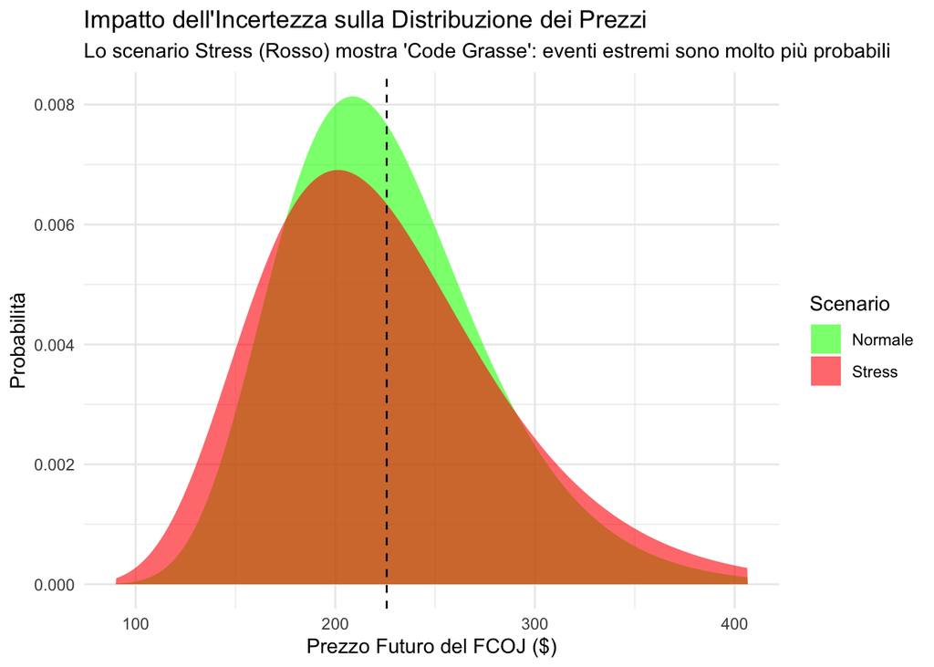

```r
# Generiamo una griglia di prezzi futuri potenziali
x_vals <- seq(F_high * 0.4, F_high * 1.8, length.out = 300)

# Densità Normale (Volatilità storica)
dens_normal <- dlnorm(x_vals, meanlog = log(F_high) - 0.5*sigma^2*T, sdlog = sigma*sqrt(T))

# Densità Stress (Volatilità 80%)
dens_stress <- dlnorm(x_vals, meanlog = log(F_high) - 0.5*sigma_stress^2*T, sdlog = sigma_stress*sqrt(T))

df_dens <- data.frame(
  Prezzo = rep(x_vals, 2), #colonna di 600 numeri, 300 per curva
  Densità = c(dens_normal, dens_stress), #risultati curva normale e curva stress
  Scenario = rep(c("Normale", "Stress"), each = 300) #etichetto le prime 300 righe come "N" e le successive come "S"
)

ggplot(df_dens, aes(x = Prezzo, y = Densità, fill = Scenario)) +
  geom_area(alpha = 0.6, position = "identity") + #per far si che si sovrappongano
  scale_fill_manual(values = c("Normale" = "green", "Stress" = "red")) +
  geom_vline(xintercept = F_high, linetype="dashed") +
  labs(title = "Impatto dell'Incertezza sulla Distribuzione dei Prezzi",
       subtitle = "Lo scenario Stress (Rosso) mostra 'Code Grasse': eventi estremi sono molto più probabili",
       x = "Prezzo Futuro del FCOJ ($)",
       y = "Probabilità") +
  theme_minimal()
```

Il grafico soprastante evidenzia visivamente la differenza tra una normale volatilità di mercato e uno scenario di “Event Risk”. La distribuzione rossa (Stress) presenta rispetto alla verde (Normale):

**Code Grasse (Fat Tails):** Le estremità della curva rossa sono più alte di quella verde. Ciò significa che la probabilità di eventi estremi (come il crollo dei prezzi ipotizzato nel film) è drasticamente superiore rispetto a quanto previsto da una distribuzione normale standard. In finanza, si dice che il mercato sta prezzando un “Cigno Nero”, ovvero un evento raro di impatto estremo.

**Implicazione per il Pricing:** Il modello di Black-Scholes standard tende a sottostimare la probabilità di questi eventi estremi (le code). Aumentando la volatilità all’80%, abbiamo forzato il modello a considerare queste “code”, giustificando così l’aumento del prezzo dell’Opzione Put osservato nella tabella precedente. Chi vende l’opzione (l’assicuratore) richiede un premio molto più alto per coprirsi dal rischio che il prezzo finisca nella “coda sinistra” della distribuzione.

## 3.4 Simulazione del Profitto (Il “Colpo” di Winthorpe e Valentine)

Nel film, una volta uscito il report, il prezzo crolla drasticamente perché non c’è nessuna gelata. Simuliamo un crollo del mercato del **40%** in un solo giorno e calcoliamo il profitto per chi aveva comprato la Put.

```r
# Il prezzo crolla del 40% dopo la notizia
F_crash <- F_high * 0.60

# Valore della Put al momento del crollo (Valore Intrinseco)
# Put Value = Max(Strike - Prezzo Mercato, 0)
put_value_crash <- max(K_stress - F_crash, 0)

# Profitto Netto = Valore Finale - Costo Opzione (Premio pagato)
profitto_netto <- put_value_crash - price_stress
roi <- (profitto_netto / price_stress) * 100

cat("--- RISULTATO OPERAZIONE ---\n")
```

```
## --- RISULTATO OPERAZIONE ---
```

```r
cat("Prezzo Strike (K):", round(K_stress, 2), "$\n")
```

```
## Prezzo Strike (K): 225.72 $
```

```r
cat("Prezzo dopo il Crollo:", round(F_crash, 2), "$\n")
```

```
## Prezzo dopo il Crollo: 135.43 $
```

```r
cat("Valore della Put (Payoff):", round(put_value_crash, 2), "$\n")
```

```
## Valore della Put (Payoff): 90.29 $
```

```r
cat("Costo Iniziale (Premio):", round(price_stress, 2), "$\n")
```

```
## Costo Iniziale (Premio): 24.63 $
```

```r
cat("Profitto Netto per Opzione:", round(profitto_netto, 2), "$\n")
```

```
## Profitto Netto per Opzione: 65.66 $
```

```r
cat("Ritorno sull'Investimento (ROI):", round(roi, 2), "%")
```

```
## Ritorno sull'Investimento (ROI): 266.57 %
```

Il profitto derivante dall’acquisto dell’opzione put è di $65,66\$$ con un Return-On-Investment pari al $266,57\%$.

# 4 Conclusioni

Il presente elaborato ha analizzato il pricing di un’opzione Put Europea su Futures FCOJ (*Frozen Concentrated Orange Juice*), confrontando l’approccio analitico classico con metodi di simulazione numerica in due scenari di mercato distinti. Lo studio si è articolato in due fasi:

1. **Analisi con Dati Reali:** Abbiamo ricostruito la serie storica del sottostante (Luglio 2025 – Gennaio 2026), stimando una volatilità storica del **66.3%**. Su tale parametro abbiamo implementato il modello di **Black (1976)** e una simulazione **Monte Carlo** con 50.000 scenari.
2. **Stress Test - Scenario “Una poltrona per due”:** Abbiamo simulato un regime di *Event Risk* tipico dell’attesa di report agricoli, ipotizzando un incremento della volatilità all’80% e analizzando l’impatto sul premio dell’opzione (Vega Risk) e sulla distribuzione dei prezzi (Fat Tails).

In conclusione, l’esercizio di un’opzione Put su Future non comporta la consegna fisica della merce. Comporta l’assegnazione di una posizione Short nel contratto Future sottostante al prezzo di Strike. Poiché il prezzo di mercato del Future è inferiore allo Strike, l’investitore ottiene immediatamente un profitto pari alla differenza, e può decidere se chiudere subito la posizione (monetizzando) o mantenere il contratto Future aperto, quindi compri l’opzione sul Future per avere la leva finanziaria del Future ma con il rischio limitato dell’Opzione.

**Risultati principali**

- *Validità del Metodo Numerico:* L’algoritmo Monte Carlo ha mostrato una convergenza robusta verso il prezzo teorico di Black-76, con uno scostamento trascurabile (confermato dall’intervallo di confidenza al 95%).
- *Valore della Copertura:* L’analisi grafica ha evidenziato come il valore temporale dell’opzione sia massimo in corrispondenza dello Strike Price (ATM).
- *Impatto dell’Incertezza:* Lo stress test ha dimostrato che, in presenza di “code grasse” (Leptocurtosi), il costo della protezione assicurativa (Hedging) aumenta drasticamente (+20%) anche a parità di prezzo del sottostante, confermando la sensibilità del modello al parametro di volatilità (Vega).

**Possibili Estensioni Future** Per rendere il modello ancora più aderente alla realtà dei mercati delle *commodities*, lo studio potrebbe essere esteso in tre direzioni:

1. *Modelli a Volatilità Stocastica:* Sostituire l’ipotesi di volatilità costante ($\sigma$) con modelli che catturano meglio lo “smile” di volatilità osservato sul mercato delle opzioni.
2. *Salto nel Prezzo (Jump Diffusion):* Introdurre nel processo stocastico una componente di salto (Processo di Poisson) per modellare meglio gli shock improvvisi tipici dei report sui raccolti (modello di *Merton*).
3. *Opzioni Americane:* Implementare algoritmi per il pricing di opzioni esercitabili prima della scadenza, essendo la maggior parte delle opzioni su Futures di tipo Americano.

# 5 Principali comandi e librerie utilizzate

*Librerie Grafiche*

**`ggplot2`**: È il pacchetto standard per la visualizzazione dati in R. A differenza dei grafici base, utilizza una “Grammatica della Grafica” che costruisce il grafico a strati (*layers*): si parte dai dati, si aggiungono gli assi (`aes`), poi le forme geometriche (`geom_line`, `geom_point`) e infine le etichette (`labs`).

*Funzioni Matematiche e Statistiche*

- **`rnorm(n, mean, sd)`**: Il “cuore” del metodo Monte Carlo. Genera $n$ numeri casuali estratti da una distribuzione Normale Standard. Nel progetto, rappresenta la componente stocastica $Z$ del Moto Browniano.
- **`pnorm(...)`**: Calcola la funzione di ripartizione della Normale Standard $\Phi(x)$. È essenziale per calcolare le probabilità $N(d_1)$ e $N(d_2)$ nella formula chiusa di Black-Scholes.
- **`pmax(...)`**: Una versione vettoriale della funzione “massimo”. A differenza di `max` (che restituisce un solo numero), `pmax` confronta due vettori elemento per elemento. È stata usata per calcolare il Payoff per tutti i 50.000 scenari contemporaneamente: $\max(K - S_T, 0)$.

*Comandi di Sistema*

- **`set.seed(123)`**: “Blocca” il generatore di numeri casuali. Serve a garantire la **riproducibilità** dell’esperimento: chiunque esegua il codice otterrà esattamente gli stessi numeri casuali e quindi gli stessi risultati e grafici.
- **`cat(...)`**: Funzione di concatenazione e stampa. Permette di combinare testo descrittivo e valori numerici variabili per generare un output leggibile nel report finale.